# LAB 2

## PART A : Prerequisite for kNN implementation.(Q1. – Q.12 may help you to implement kNN on your own )

### 1. Create two vectors using numpy and check how many values are equal in the two vectors.

```python
import numpy as np
import pandas as pd
import matplotlib.pyplot as plt
plt.style.use("Solarize_Light2")
np.random.seed(9)
np.set_printoptions(suppress=True)
```

```python
V1 = np.array([1, 6, 7, 9])
V2 = np.array([1, 0, 6, 9])
```

```python
V1==V2
```

```
array([ True, False, False,  True])
```

```python
print("Number of values common in V1 & V2: ", np.sum(V1==V2))
```

```
Number of values common in V1 & V2:  2
```

### 2. Matrix creation using numpy

#### a. Create a matrix M with 10 rows and 3 columns and populate with random values.

```python
rng = np.random.default_rng()
```

```python
M = rng.integers(1000, size=(10, 3))
M
```

```
array([[304, 391, 437],
       [ 99, 424, 258],
       [196, 278, 981],
       [440, 279, 209],
       [269, 124, 934],
       [ 70,  96, 497],
       [421, 340, 501],
       [681, 869, 795],
       [561, 766,  69],
       [337, 785, 383]], dtype=int64)
```

#### b. Print size of M.

```python
print("Size of M: ", M.shape)
```

```
Size of M:  (10, 3)
```

#### c. Print only number of rows of M

```python
print("Number of rows of M: ", M.shape[0])
```

```
Number of rows of M:  10
```

#### d. Print only number of columns of M

```python
print("Number of columns of M: ", M.shape[1])
```

```
Number of columns of M:  3
```

#### e. Write a simple loop to modify third column as follows: If sum of first two columns is divisible by 4, Y should be 1 else 0.

```python
for i in range(len(M)):
    s = M[i][0] + M[i][1]
    if( (s % 4) == 0):
        M[i][2] = 1
    else:
        M[i][2] = 0
```

```python
M
```

```
array([[304, 391,   0],
       [ 99, 424,   0],
       [196, 278,   0],
       [440, 279,   0],
       [269, 124,   0],
       [ 70,  96,   0],
       [421, 340,   0],
       [681, 869,   0],
       [561, 766,   0],
       [337, 785,   0]], dtype=int64)
```

### 3. Create a pandas dataframe ‘df’ from the created matrix M and name the columns as X1,X2, and Y.

```python
df = pd.DataFrame(M, columns = ['X1', 'X2', 'Y'])
df
```

|  | X1 | X2 | Y |
| --- | --- | --- | --- |
| 0 | 304 | 391 | 0 |
| 1 | 99 | 424 | 0 |
| 2 | 196 | 278 | 0 |
| 3 | 440 | 279 | 0 |
| 4 | 269 | 124 | 0 |
| 5 | 70 | 96 | 0 |
| 6 | 421 | 340 | 0 |
| 7 | 681 | 869 | 0 |
| 8 | 561 | 766 | 0 |
| 9 | 337 | 785 | 0 |

### 4. Plot X1 and X2 using scatter plot. Color (X1,X2) red if corresponding Y is 1 else blue.

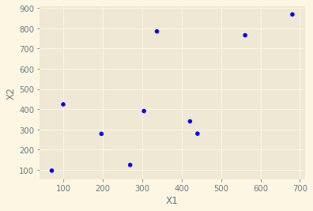

```python
'''y = M[:,2]
col = np.where(y==1,'r','b')
plt.scatter(M[:,0], M[:,1], c=col)
plt.show()'''
col = df.Y.map({0:'b', 1:'r'})
df.plot.scatter(x='X1', y='X2', c=col)
plt.show()
```

### 5. a. For two columns X1, X2, find squared error : (x1 – x2)^2

```python
Z = np.square((M[:,0]-M[:,1]))
print("squared error : (x1 – x2)^2 = \n", Z)
```

```
squared error : (x1 – x2)^2 =
 [  7569 105625   6724  25921  21025    676   6561  35344  42025 200704]
```

#### b. Find sum of the squared error

```python
Zsum = np.sum(Z)
print("Sum of [squared error : (x1 – x2)^2] = ", Zsum)
```

```
Sum of [squared error : (x1 – x2)^2] =  452174
```

### Compare result with inbuilt function numpy.linalg.norm(a-b) where a is first row and b is second row.

```python
ed = np.sqrt(np.sum(np.square(M[:,0] - M[:,1])))
print("Euclidean Distance = ", ed)
```

```
Euclidean Distance =  672.4388448030052
```

```python
print("Euclidean Distance = ", np.linalg.norm(M[:,0]-M[:,1]))
```

```
Euclidean Distance =  672.4388448030052
```

### 7. Create a vector V with two random values. Find the Euclidean distance between each row of M with V. Store the distance in a vector and print

```python
V = rng.integers(1000, size=(2))
V
```

```
array([464, 555], dtype=int64)
```

```python
eu_dist = np.linalg.norm(M[:, 0:2] - V, axis=1)
```

```python
print("Euclidean Distance between single point and matrix M:\n", eu_dist)
```

```
Euclidean Distance between single point and matrix M:
 [229.12005587 387.7963383  385.42573863 277.04151313 473.06024986
 604.91073722 219.25783908 381.68704458 232.22833591 262.73370549]
```

### 8. Manipulate matrix Create a matrix A with 10 rows and 2 columns. Add a new column to a matrix. (Use np.column_stack) Add a new row to a matrix(Use np.vstack)

```python
A = rng.integers(1000, size=(10, 2))
print(A)
```

```
[[967 646]
 [992 927]
 [745 548]
 [495 734]
 [446  30]
 [540 239]
 [995   4]
 [399 568]
 [850 994]
 [119 253]]
```

```python
C = rng.integers(1000, size=10)
print(C)
```

```
[480 339 191 711 507 762 458  55 312 281]
```

```python
A = np.column_stack((A, C))
print(A)
```

```
[[967 646 480]
 [992 927 339]
 [745 548 191]
 [495 734 711]
 [446  30 507]
 [540 239 762]
 [995   4 458]
 [399 568  55]
 [850 994 312]
 [119 253 281]]
```

```python
R = rng.integers(1000, size=3)
print(R)
```

```
[552  88 489]
```

```python
A = np.vstack((A, R))
print(A)
```

```
[[967 646 480]
 [992 927 339]
 [745 548 191]
 [495 734 711]
 [446  30 507]
 [540 239 762]
 [995   4 458]
 [399 568  55]
 [850 994 312]
 [119 253 281]
 [552  88 489]]
```

### 9. Create a matrix M’ with two columns X1’, X2’ and populate with random values. Find the Euclidean distance between each row of M’ with each row of M(excluding the last column Y) created in Q.2 Store the distance in a matrix Dist with 3 columns. First column is the row id of M, second column is the row id of M’, and the third column is distance value

```python
from sklearn.metrics.pairwise import euclidean_distances
```

```python
M_ = rng.integers(1000, size=(10, 2))
M_
```

```
array([[391, 213],
       [270, 238],
       [ 94, 541],
       [314, 535],
       [297, 103],
       [656, 664],
       [575, 274],
       [933, 624],
       [ 32, 696],
       [211, 254]], dtype=int64)
```

```python
Dist = np.linalg.norm(M[:,0:2] - M_, axis=1)
Dist
```

```
array([198.12369873, 252.65985039, 282.08686605, 285.32788157,
        35.        , 816.10048401, 167.54700833, 351.4669259 ,
       533.61128174, 545.74444569])
```

```python
def ed(v1, v2):
    return np.linalg.norm(v1-v2)
```

```python
M2 = M[:,0:2]
Dist = np.empty((0, 3))
for i in range(len(M_)):
    for j in range(len(M2)):
        d = ed(M_[i], M2[j])
        Dist = np.vstack((Dist,np.array([j, i, d])))


Dist = np.round(Dist, 4)
```

### 10. Sort Dist matrix based on last column.

```python
Dist = Dist[Dist[:,2].argsort()]
```

```python
print(Dist)
```

```
[[   2.        9.       28.3019]
 [   4.        4.       35.    ]
 [   3.        0.       82.201 ]
 [   2.        1.       84.119 ]
 [   4.        1.      114.0044]
 [   1.        2.      117.1068]
 [   6.        0.      130.4952]
 [   3.        6.      135.0926]
 [   8.        5.      139.3879]
 [   4.        9.      142.3517]
 [   0.        3.      144.3468]
 [   4.        0.      151.0132]
 [   0.        1.      156.7323]
 [   0.        9.      165.5838]
 [   6.        6.      167.547 ]
 [   3.        1.      174.8742]
 [   6.        1.      182.2224]
 [   0.        0.      198.1237]
 [   2.        4.      202.0544]
 [   1.        9.      203.578 ]
 [   2.        0.      205.548 ]
 [   7.        5.      206.5188]
 [   5.        9.      211.7664]
 [   6.        3.      222.4275]
 [   3.        4.      226.7708]
 [   6.        9.      226.9273]
 [   5.        4.      227.1079]
 [   3.        9.      230.3606]
 [   1.        3.      241.9628]
 [   5.        1.      245.2835]
 [   9.        3.      251.0558]
 [   1.        1.      252.6599]
 [   0.        2.      258.0698]
 [   6.        4.      267.479 ]
 [   1.        8.      280.1303]
 [   2.        2.      282.0869]
 [   2.        3.      282.795 ]
 [   3.        3.      285.3279]
 [   0.        4.      288.0851]
 [   0.        6.      295.1779]
```

[output cut: 45 more lines]

```
 [   4.        5.      664.3561]
 [   0.        7.      670.7682]
 [   7.        8.      671.6621]
 [   7.        2.      672.4232]
 [   9.        4.      683.172 ]
 [   8.        4.      713.6281]
 [   7.        0.      717.2419]
 [   7.        1.      753.0485]
 [   7.        9.      774.0317]
 [   2.        7.      814.1775]
 [   5.        5.      816.1005]
 [   4.        7.      831.2015]
 [   7.        4.      856.8617]
 [   1.        7.      857.6456]
 [   5.        7.     1011.708 ]]
```

### 11. a. Get initial k rows from sorted matrix

```python
k = 10
M3 = Dist[:k]
print(M3)
```

```
[[  2.       9.      28.3019]
 [  4.       4.      35.    ]
 [  3.       0.      82.201 ]
 [  2.       1.      84.119 ]
 [  4.       1.     114.0044]
 [  1.       2.     117.1068]
 [  6.       0.     130.4952]
 [  3.       6.     135.0926]
 [  8.       5.     139.3879]
 [  4.       9.     142.3517]]
```

#### b. Get the rows corresponding to these k rows from M.

```python
M4 = np.empty((0, 3))
for rw in M3:
    M4 = np.vstack((M4,M[int(rw[0])]))
```

```python
M4
```

```
array([[196., 278.,   0.],
       [269., 124.,   0.],
       [440., 279.,   0.],
       [196., 278.,   0.],
       [269., 124.,   0.],
       [ 99., 424.,   0.],
       [421., 340.,   0.],
       [440., 279.,   0.],
       [561., 766.,   0.],
       [269., 124.,   0.]])
```

### 12. Find the number of 1s and number of 0s in the rows of M matrix, corresponding to the k rows found in Q. 11. Print 1 if the number of 1s are more else print 0.

```python
if(list(M4[:,2]).count(1.0) > list(M4[:,2]).count(0.0)):
    print("1")
else:
    print("0")
```

```
0
```

## PART B: kNN implementation

### a. Load diabetes dataset as done in Lab 1.

```python
path='diabetes.csv'
data=pd.read_csv(path)
```

### b. Peek at few rows as done in Lab 1

```python
data
```

|  | Pregnancies | Glucose | BloodPressure | SkinThickness | Insulin | BMI | DiabetesPedigreeFunction | Age | Outcome |
| --- | --- | --- | --- | --- | --- | --- | --- | --- | --- |
| 0 | 6 | 148 | 72 | 35 | 0 | 33.6 | 0.627 | 50 | 1 |
| 1 | 1 | 85 | 66 | 29 | 0 | 26.6 | 0.351 | 31 | 0 |
| 2 | 8 | 183 | 64 | 0 | 0 | 23.3 | 0.672 | 32 | 1 |
| 3 | 1 | 89 | 66 | 23 | 94 | 28.1 | 0.167 | 21 | 0 |
| 4 | 0 | 137 | 40 | 35 | 168 | 43.1 | 2.288 | 33 | 1 |
| ... | ... | ... | ... | ... | ... | ... | ... | ... | ... |
| 763 | 10 | 101 | 76 | 48 | 180 | 32.9 | 0.171 | 63 | 0 |
| 764 | 2 | 122 | 70 | 27 | 0 | 36.8 | 0.340 | 27 | 0 |
| 765 | 5 | 121 | 72 | 23 | 112 | 26.2 | 0.245 | 30 | 0 |
| 766 | 1 | 126 | 60 | 0 | 0 | 30.1 | 0.349 | 47 | 1 |
| 767 | 1 | 93 | 70 | 31 | 0 | 30.4 | 0.315 | 23 | 0 |

768 rows × 9 columns

### c. Split the dataset into 80% training and 20% testing using numpy slicing.

```python
X = data.iloc[:,:8]
y = data.iloc[:,-1:]
```

```python
idx_80 = int(len(data) * 0.80)
X_train_1, X_test_1, y_train_1, y_test_1 = X[:idx_80], X[idx_80:], y[:idx_80], y[idx_80:]
```

```python
X_train_1
```

|  | Pregnancies | Glucose | BloodPressure | SkinThickness | Insulin | BMI | DiabetesPedigreeFunction | Age |
| --- | --- | --- | --- | --- | --- | --- | --- | --- |
| 0 | 6 | 148 | 72 | 35 | 0 | 33.6 | 0.627 | 50 |
| 1 | 1 | 85 | 66 | 29 | 0 | 26.6 | 0.351 | 31 |
| 2 | 8 | 183 | 64 | 0 | 0 | 23.3 | 0.672 | 32 |
| 3 | 1 | 89 | 66 | 23 | 94 | 28.1 | 0.167 | 21 |
| 4 | 0 | 137 | 40 | 35 | 168 | 43.1 | 2.288 | 33 |
| ... | ... | ... | ... | ... | ... | ... | ... | ... |
| 609 | 1 | 111 | 62 | 13 | 182 | 24.0 | 0.138 | 23 |
| 610 | 3 | 106 | 54 | 21 | 158 | 30.9 | 0.292 | 24 |
| 611 | 3 | 174 | 58 | 22 | 194 | 32.9 | 0.593 | 36 |
| 612 | 7 | 168 | 88 | 42 | 321 | 38.2 | 0.787 | 40 |
| 613 | 6 | 105 | 80 | 28 | 0 | 32.5 | 0.878 | 26 |

614 rows × 8 columns

### d. Use inbuilt function to do splitting and interpret results

```python
from sklearn.model_selection import train_test_split
X_train, X_test, y_train, y_test = train_test_split(X, y, test_size=0.20, shuffle=False)
```

```python
X_train
```

|  | Pregnancies | Glucose | BloodPressure | SkinThickness | Insulin | BMI | DiabetesPedigreeFunction | Age |
| --- | --- | --- | --- | --- | --- | --- | --- | --- |
| 0 | 6 | 148 | 72 | 35 | 0 | 33.6 | 0.627 | 50 |
| 1 | 1 | 85 | 66 | 29 | 0 | 26.6 | 0.351 | 31 |
| 2 | 8 | 183 | 64 | 0 | 0 | 23.3 | 0.672 | 32 |
| 3 | 1 | 89 | 66 | 23 | 94 | 28.1 | 0.167 | 21 |
| 4 | 0 | 137 | 40 | 35 | 168 | 43.1 | 2.288 | 33 |
| ... | ... | ... | ... | ... | ... | ... | ... | ... |
| 609 | 1 | 111 | 62 | 13 | 182 | 24.0 | 0.138 | 23 |
| 610 | 3 | 106 | 54 | 21 | 158 | 30.9 | 0.292 | 24 |
| 611 | 3 | 174 | 58 | 22 | 194 | 32.9 | 0.593 | 36 |
| 612 | 7 | 168 | 88 | 42 | 321 | 38.2 | 0.787 | 40 |
| 613 | 6 | 105 | 80 | 28 | 0 | 32.5 | 0.878 | 26 |

614 rows × 8 columns

#### Interpretation: Both normal array slicing and train_test_split produced same results because of shuffle=False property used in train_test_split function

### e. Normalize the training dataset using StandardScaler as done in Lab 1. Is it required to Normalize the testing dataset (X_test) too?

```python
from sklearn.preprocessing import StandardScaler
from sklearn import preprocessing

mnormalizer = preprocessing.Normalizer().fit(X_train)
X_train_norm = mnormalizer.transform(X_train)
X_test_norm = mnormalizer.transform(X_test)

std_scale = preprocessing.StandardScaler().fit(X_train)
X_train_std = std_scale.transform(X_train)
X_test_std  = std_scale.transform(X_test)
```

### f. Invoke inbuilt kNN function. Interpret the output obtained.

```python
from sklearn.neighbors import KNeighborsClassifier
classifier = KNeighborsClassifier(n_neighbors=5)
classifier.fit(X_train, y_train.values.ravel())
y_pred = classifier.predict(X_test)
```

```python
y_pred
```

```
array([1, 0, 0, 0, 0, 1, 0, 0, 1, 0, 0, 0, 0, 0, 1, 0, 0, 0, 0, 0, 0, 1,
       1, 0, 0, 0, 0, 0, 0, 0, 0, 1, 1, 1, 0, 0, 0, 0, 0, 0, 0, 1, 0, 1,
       0, 0, 1, 1, 1, 0, 0, 0, 0, 0, 0, 1, 1, 0, 0, 1, 0, 1, 1, 0, 0, 0,
       0, 1, 0, 0, 0, 0, 1, 0, 0, 1, 1, 1, 0, 0, 0, 1, 1, 0, 0, 0, 0, 0,
       1, 1, 0, 0, 0, 1, 1, 0, 0, 0, 0, 0, 1, 0, 1, 0, 0, 1, 0, 1, 0, 0,
       0, 1, 1, 0, 1, 0, 0, 0, 1, 1, 0, 0, 0, 0, 0, 1, 1, 0, 0, 0, 1, 0,
       1, 0, 1, 0, 0, 0, 0, 1, 1, 0, 0, 1, 0, 1, 0, 1, 0, 1, 0, 0, 1, 0],
      dtype=int64)
```

#### Interpretation: y_pred contains predictions derived from X_test on basis of model KNeighborsClassifier trained with train dataset X_train

### g. Evaluate kNN. Explain the output obtained.

```python
from sklearn.metrics import classification_report, confusion_matrix
print(confusion_matrix(y_test, y_pred))
print(classification_report(y_test, y_pred))
```

```
[[78 21]
 [25 30]]
              precision    recall  f1-score   support

           0       0.76      0.79      0.77        99
           1       0.59      0.55      0.57        55

    accuracy                           0.70       154
   macro avg       0.67      0.67      0.67       154
weighted avg       0.70      0.70      0.70       154
```

#### Interpretation: accuracy of the KNeighborsClassifier model for this dataset is 70%. Precision, recall and f1-score of predicting 0 is 0.76, 0.79 and 0.77 respectively. Precision, recall and f1-score of predicting 1 is 0.59, 0.55 and 0.57 respectively.

### h. Find the total number of correct predictions, Type 1 error(FP) and Type 2 error(FN)

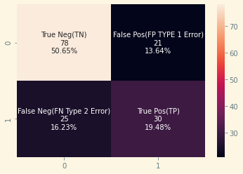

```python
from sklearn import metrics
cf_matrix = metrics.confusion_matrix(y_test, y_pred)
group_names = ['True Neg(TN)', 'False Pos(FP TYPE 1 Error)', 'False Neg(FN Type 2 Error)', 'True Pos(TP)']
group_counts = ["{0:0.0f}".format(value) for value in cf_matrix.flatten()]
group_percentages = ["{0:.2%}".format(value) for value in cf_matrix.flatten()/np.sum(cf_matrix)]
labels = [f"{v1}\n{v2}\n{v3}" for v1, v2, v3 in zip(group_names,group_counts,group_percentages)]
labels = np.asarray(labels).reshape(2,2)
import seaborn as sns
sns.heatmap(cf_matrix, annot=labels, fmt='')
```

### i. Plot the Type 1 and Type 2 error for different values of ‘k’ values. (X-axis : k value and Y-axis : Type 1 error as well as Type 2 error).

```python
def KNN(k, X_train, y_train):
    classifier = KNeighborsClassifier(n_neighbors=k)
    classifier.fit(X_train, y_train.values.ravel())
    y_pred = classifier.predict(X_test)
    return y_pred
```

```python
y_pred_list = []
num_of_k = 30
for k in range(1, num_of_k):
    y_pred_list.append(KNN(k, X_train, y_train))
```

```python
cf_matrix[0][1], cf_matrix[1][0]
```

```
(21, 25)
```

```python
len(y_pred_list)
```

```
29
```

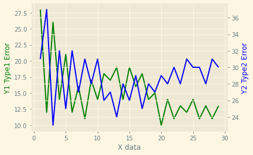

```python
fig, ax1 = plt.subplots()
x = list(range(1, num_of_k))
y1 = []
y2 = []
for k in range(0, num_of_k-1):
    cf_matrix = metrics.confusion_matrix(y_test, y_pred_list[k])
    y1.append(cf_matrix[0][1])
    y2.append(cf_matrix[1][0])
ax2 = ax1.twinx()
ax1.plot(x, y1, 'g-')
ax2.plot(x, y2, 'b-')

ax1.set_xlabel('X data')
ax1.set_ylabel('Y1 Type1 Error', color='g')
ax2.set_ylabel('Y2 Type2 Error', color='b')

plt.show()
```